# Radiation Model

## Background research

As seen in the image below and as explained in Caleb Robinson and Bistra Dilkina’s paper, [“A Machine Learning Approach to Modeling Human Migration”](https://doi.org/10.1145/3209811.3209868), the traditional migration models can be written as the product of two parts: $T_{ij} = G_i * P_{ij}$.

- $T_{ij}$ is the number of people moving from every zone i to every other zone j
- $G_i = \alpha * m_i$ is the production function that estimates number of people leaving zone i
  - $m_i$ is the population of zone i and $\alpha$ is a parameter tuned using historical data
- $P_{ij}$ is the probability of a move occurring from i to j
  - Robinson and Dilkina note that the probability of moving from i to all other destinations j should sum to 1

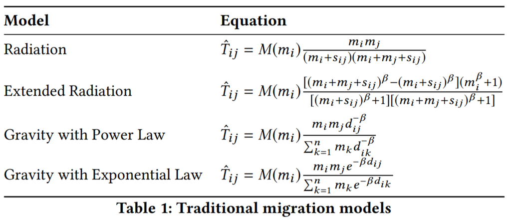

## Create table for distances between states

Before we can run the radiation model, we need to know the distance between state i and state j for all combinations of (i, j). If we haven’t already done so, let’s create a table with this information and write it out to a CSV.

```r
if (!file.exists(here("results", "distances_between_states.csv"))) {
  create_distance_matrix()
}
```

## Create intervening opportunities matrix

In addition to the distances information, we’ll need to create a matrix, $S_{ij}$ that will provide us with intervening opportunities between zones i and j that migrants would likely consider while moving to zone j. $S_{ij}$ is defined as the population of all zones between i and j (excluding zones i and j) within a circle centered at i with radius d_ij. This means we’ll need distance and population estimate information for each combination of (i, j) states.

In /R/migration_models.R, you’ll find a definition for two functions: `get_intervening_opps()` and `generate_int_opp_files()`.

- `get_intervening_opps()` is the function containing all the intervening opportunities mathematical calculations and writes out a migration matrix, $S_{ij}$, to a CSV.
- `generate_int_opp_files()` is the function that calls `get_intervening_opps()` for each column (year) of data in the population estimates table we created earlier.

This allows us to more efficiently create and write out the intervening opportunities matrices for each of the years between 2009-2017 which will be used in the radiation model in the next step.

```r
pop_estimates <- read.csv(here("results", "data_cleaning_results", "population_estimates.csv"))
locations <- read.csv(here("results", "distances_between_states.csv"))
columns <- colnames(pop_estimates)

# create appropriate results directory if it doesn't already exist
if (!dir.exists(here("results", "radiation_model_results"))) {
  dir.create(here("results", "radiation_model_results"))
}

result <- map(columns, ~ generate_int_opp_files(., pop_estimates, locations))
```

## Using the radiation model

Now we can generate radiation model migration matrices using the same setup we’ve used for the gravity model and intervening opportunities files.

In /R/migration_models.R, you’ll find a definition for two functions: `radiation_model()` and `generate_radiation_matrices()`.

- `radiation_model()` is the function containing all the radiation model mathematical calculations and returns a migration matrix, $T_{ij}$.
- `generate_radiation_matrices()` is the function that calls `radiation_model()` for each column (year) of data in the population estimates table we created earlier.

```r
pop_estimates <- read.csv(here("results", "data_cleaning_results", "population_estimates.csv"))
columns <- colnames(pop_estimates)
alpha <- 0.3

result <- map(columns, ~ generate_radiation_matrices(., pop_estimates, alpha))
```